# Risk Factor Analysis

## Outcome Variable

**Outcome Variable:** stunted

## Predictor Variables

**Intervention Variable:** birthwt

**Adjustment Set:**

unadjusted

## Stratifying Variables

The analysis was stratified on these variable(s):

- agecat
- studyid

The following strata were considered:

- agecat: 12 months, studyid: ki0047075b-MAL-ED
- agecat: 12 months, studyid: ki1000108-CMC-V-BCS-2002
- agecat: 12 months, studyid: ki1000108-IRC
- agecat: 12 months, studyid: ki1000109-EE
- agecat: 12 months, studyid: ki1017093b-PROVIDE
- agecat: 12 months, studyid: ki1017093c-NIH-Crypto
- agecat: 12 months, studyid: ki1066203-TanzaniaChild2
- agecat: 12 months, studyid: ki1101329-Keneba
- agecat: 12 months, studyid: ki1126311-ZVITAMBO
- agecat: 12 months, studyid: ki1135781-COHORTS
- agecat: 18 months, studyid: ki0047075b-MAL-ED
- agecat: 18 months, studyid: ki1000108-CMC-V-BCS-2002
- agecat: 18 months, studyid: ki1000108-IRC
- agecat: 18 months, studyid: ki1000109-EE
- agecat: 18 months, studyid: ki1017093b-PROVIDE
- agecat: 18 months, studyid: ki1017093c-NIH-Crypto
- agecat: 18 months, studyid: ki1066203-TanzaniaChild2
- agecat: 18 months, studyid: ki1101329-Keneba
- agecat: 18 months, studyid: ki1126311-ZVITAMBO
- agecat: 18 months, studyid: ki1135781-COHORTS
- agecat: 24 months, studyid: ki0047075b-MAL-ED
- agecat: 24 months, studyid: ki1000108-CMC-V-BCS-2002
- agecat: 24 months, studyid: ki1000108-IRC
- agecat: 24 months, studyid: ki1017093b-PROVIDE
- agecat: 24 months, studyid: ki1017093c-NIH-Crypto
- agecat: 24 months, studyid: ki1066203-TanzaniaChild2
- agecat: 24 months, studyid: ki1101329-Keneba
- agecat: 24 months, studyid: ki1126311-ZVITAMBO
- agecat: 24 months, studyid: ki1135781-COHORTS
- agecat: 3 months, studyid: ki0047075b-MAL-ED
- agecat: 3 months, studyid: ki1000108-CMC-V-BCS-2002
- agecat: 3 months, studyid: ki1000108-IRC
- agecat: 3 months, studyid: ki1000109-EE
- agecat: 3 months, studyid: ki1017093b-PROVIDE
- agecat: 3 months, studyid: ki1017093c-NIH-Crypto
- agecat: 3 months, studyid: ki1066203-TanzaniaChild2
- agecat: 3 months, studyid: ki1101329-Keneba
- agecat: 3 months, studyid: ki1126311-ZVITAMBO
- agecat: 3 months, studyid: ki1135781-COHORTS
- agecat: 6 months, studyid: ki0047075b-MAL-ED
- agecat: 6 months, studyid: ki1000108-CMC-V-BCS-2002
- agecat: 6 months, studyid: ki1000108-IRC
- agecat: 6 months, studyid: ki1000109-EE
- agecat: 6 months, studyid: ki1017093b-PROVIDE
- agecat: 6 months, studyid: ki1017093c-NIH-Crypto
- agecat: 6 months, studyid: ki1066203-TanzaniaChild2
- agecat: 6 months, studyid: ki1101329-Keneba
- agecat: 6 months, studyid: ki1126311-ZVITAMBO
- agecat: 6 months, studyid: ki1135781-COHORTS
- agecat: 9 months, studyid: ki0047075b-MAL-ED
- agecat: 9 months, studyid: ki1000108-CMC-V-BCS-2002
- agecat: 9 months, studyid: ki1000108-IRC
- agecat: 9 months, studyid: ki1000109-EE
- agecat: 9 months, studyid: ki1017093b-PROVIDE
- agecat: 9 months, studyid: ki1017093c-NIH-Crypto
- agecat: 9 months, studyid: ki1066203-TanzaniaChild2
- agecat: 9 months, studyid: ki1101329-Keneba
- agecat: 9 months, studyid: ki1126311-ZVITAMBO
- agecat: 9 months, studyid: ki1135781-COHORTS
- agecat: Birth, studyid: ki0047075b-MAL-ED
- agecat: Birth, studyid: ki1000108-CMC-V-BCS-2002
- agecat: Birth, studyid: ki1000108-IRC
- agecat: Birth, studyid: ki1000109-EE
- agecat: Birth, studyid: ki1017093c-NIH-Crypto
- agecat: Birth, studyid: ki1101329-Keneba
- agecat: Birth, studyid: ki1126311-ZVITAMBO
- agecat: Birth, studyid: ki1135781-COHORTS

### Dropped Strata

Some strata were dropped due to rare outcomes:

- agecat: 12 months, studyid: ki1017093b-PROVIDE
- agecat: 12 months, studyid: ki1017093c-NIH-Crypto
- agecat: 18 months, studyid: ki1017093b-PROVIDE
- agecat: 24 months, studyid: ki1017093b-PROVIDE
- agecat: 24 months, studyid: ki1017093c-NIH-Crypto
- agecat: 24 months, studyid: ki1066203-TanzaniaChild2
- agecat: 3 months, studyid: ki1000108-IRC
- agecat: 3 months, studyid: ki1017093b-PROVIDE
- agecat: 3 months, studyid: ki1017093c-NIH-Crypto
- agecat: 3 months, studyid: ki1066203-TanzaniaChild2
- agecat: 6 months, studyid: ki1017093b-PROVIDE
- agecat: 9 months, studyid: ki1017093b-PROVIDE
- agecat: Birth, studyid: ki1000108-CMC-V-BCS-2002
- agecat: Birth, studyid: ki1000108-IRC
- agecat: Birth, studyid: ki1000109-EE
- agecat: Birth, studyid: ki1017093c-NIH-Crypto
- agecat: Birth, studyid: ki1101329-Keneba

## Methods Detail

We’re interested in the causal parameters $E[Y_a]$ for all values of $a \in \mathcal{A}$. These parameters represent the mean outcome if, possibly contrary to fact, we intervened to set all units to have $A=a$. Under the randomization and positivity assumptions, these are identified by the statistical parameters $\psi_a=E_W[E_{Y|A,W}(Y|A=a,W)]$. In addition, we’re interested in the mean of $Y$, $E[Y]$ under no intervention (the observed mean). We will estimate these parameters by using SuperLearner to fit the relevant likelihood factors – $E_{Y|A,W}(Y|A=a,W)$ and $p(A=a|W)$, and then updating our likelihood fit using a joint TMLE.

For unadjusted analyses ($W=\{\}$), initial likelihoods were estimated using Lrnr_glm to estimate the simple $E(Y|A)$ and Lrnr_mean to estimate $p(A)$. For adjusted analyses, a small library containing Lrnr_glmnet, Lrnr_xgboost, and Lrnr_mean was used.

Having estimated these parameters, we will then use the delta method to estimate relative risks and attributable risks relative to a prespecified baseline level of $A$.

# Results Detail

## Results Plots

[figure not shown]

[figure not shown]

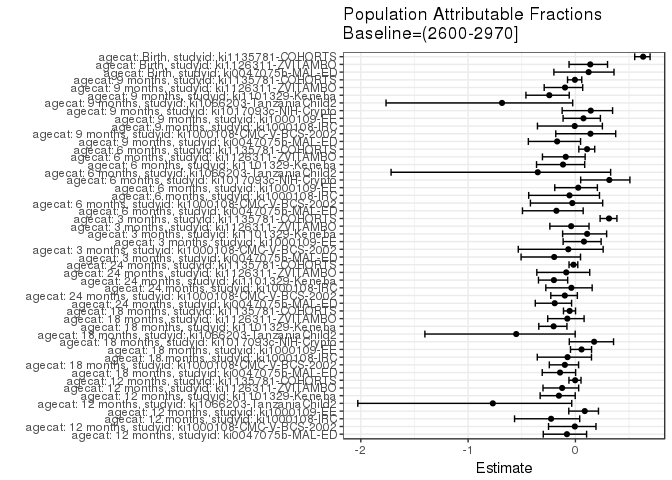

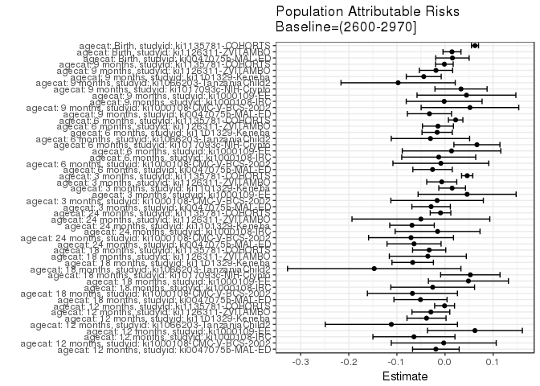

## Data Summary

| agecat | studyid | A | n | nA | nAY0 | nAY1 |
| --- | --- | --- | --- | --- | --- | --- |
| 12 months | ki0047075b-MAL-ED | (2600-2970] | 1468 | 319 | 236 | 83 |
| 12 months | ki0047075b-MAL-ED | (2970-3302.75] | 1468 | 481 | 379 | 102 |
| 12 months | ki0047075b-MAL-ED | <=2600 | 1468 | 252 | 145 | 107 |
| 12 months | ki0047075b-MAL-ED | >3302.75 | 1468 | 416 | 354 | 62 |
| 12 months | ki1000108-CMC-V-BCS-2002 | (2600-2970] | 368 | 82 | 41 | 41 |
| 12 months | ki1000108-CMC-V-BCS-2002 | (2970-3302.75] | 368 | 133 | 66 | 67 |
| 12 months | ki1000108-CMC-V-BCS-2002 | <=2600 | 368 | 90 | 32 | 58 |
| 12 months | ki1000108-CMC-V-BCS-2002 | >3302.75 | 368 | 63 | 46 | 17 |
| 12 months | ki1000108-IRC | (2600-2970] | 400 | 123 | 80 | 43 |
| 12 months | ki1000108-IRC | (2970-3302.75] | 400 | 116 | 98 | 18 |
| 12 months | ki1000108-IRC | <=2600 | 400 | 100 | 56 | 44 |
| 12 months | ki1000108-IRC | >3302.75 | 400 | 61 | 52 | 9 |
| 12 months | ki1000109-EE | (2600-2970] | 357 | 92 | 32 | 60 |
| 12 months | ki1000109-EE | (2970-3302.75] | 357 | 66 | 22 | 44 |
| 12 months | ki1000109-EE | <=2600 | 357 | 167 | 27 | 140 |
| 12 months | ki1000109-EE | >3302.75 | 357 | 32 | 21 | 11 |
| 12 months | ki1017093b-PROVIDE | (2600-2970] | 153 | 59 | 40 | 19 |
| 12 months | ki1017093b-PROVIDE | (2970-3302.75] | 153 | 38 | 36 | 2 |
| 12 months | ki1017093b-PROVIDE | <=2600 | 153 | 46 | 23 | 23 |
| 12 months | ki1017093b-PROVIDE | >3302.75 | 153 | 10 | 10 | 0 |
| 12 months | ki1017093c-NIH-Crypto | (2600-2970] | 706 | 216 | 171 | 45 |
| 12 months | ki1017093c-NIH-Crypto | (2970-3302.75] | 706 | 165 | 142 | 23 |
| 12 months | ki1017093c-NIH-Crypto | <=2600 | 706 | 246 | 147 | 99 |
| 12 months | ki1017093c-NIH-Crypto | >3302.75 | 706 | 79 | 75 | 4 |
| 12 months | ki1066203-TanzaniaChild2 | (2600-2970] | 352 | 39 | 29 | 10 |
| 12 months | ki1066203-TanzaniaChild2 | (2970-3302.75] | 352 | 151 | 125 | 26 |
| 12 months | ki1066203-TanzaniaChild2 | <=2600 | 352 | 26 | 21 | 5 |
| 12 months | ki1066203-TanzaniaChild2 | >3302.75 | 352 | 136 | 126 | 10 |
| 12 months | ki1101329-Keneba | (2600-2970] | 1607 | 492 | 350 | 142 |
| 12 months | ki1101329-Keneba | (2970-3302.75] | 1607 | 510 | 433 | 77 |

[output cut: 250 more lines]

## Results Table

### Parameter: TSM

| agecat | studyid | intervention_level | baseline_level | estimate | ci_lower | ci_upper |
| --- | --- | --- | --- | --- | --- | --- |
| 12 months | ki0047075b-MAL-ED | (2600-2970] | NA | 0.2601881 | 0.2120260 | 0.3083502 |
| 12 months | ki0047075b-MAL-ED | (2970-3302.75] | NA | 0.2120582 | 0.1755157 | 0.2486007 |
| 12 months | ki0047075b-MAL-ED | <=2600 | NA | 0.4246032 | 0.3635552 | 0.4856511 |
| 12 months | ki0047075b-MAL-ED | >3302.75 | NA | 0.1490385 | 0.1148048 | 0.1832721 |
| 12 months | ki1000108-CMC-V-BCS-2002 | (2600-2970] | NA | 0.5000000 | 0.3916318 | 0.6083682 |
| 12 months | ki1000108-CMC-V-BCS-2002 | (2970-3302.75] | NA | 0.5037594 | 0.4186709 | 0.5888479 |
| 12 months | ki1000108-CMC-V-BCS-2002 | <=2600 | NA | 0.6444444 | 0.5454150 | 0.7434739 |
| 12 months | ki1000108-CMC-V-BCS-2002 | >3302.75 | NA | 0.2698413 | 0.1600844 | 0.3795981 |
| 12 months | ki1000108-IRC | (2600-2970] | NA | 0.3495935 | 0.2652186 | 0.4339684 |
| 12 months | ki1000108-IRC | (2970-3302.75] | NA | 0.1551724 | 0.0892013 | 0.2211435 |
| 12 months | ki1000108-IRC | <=2600 | NA | 0.4400000 | 0.3425881 | 0.5374119 |
| 12 months | ki1000108-IRC | >3302.75 | NA | 0.1475410 | 0.0584323 | 0.2366496 |
| 12 months | ki1000109-EE | (2600-2970] | NA | 0.6521739 | 0.5547140 | 0.7496338 |
| 12 months | ki1000109-EE | (2970-3302.75] | NA | 0.6666667 | 0.5527784 | 0.7805549 |
| 12 months | ki1000109-EE | <=2600 | NA | 0.8383234 | 0.7824083 | 0.8942384 |
| 12 months | ki1000109-EE | >3302.75 | NA | 0.3437500 | 0.1789572 | 0.5085428 |
| 12 months | ki1066203-TanzaniaChild2 | (2600-2970] | NA | 0.2564103 | 0.1191743 | 0.3936462 |
| 12 months | ki1066203-TanzaniaChild2 | (2970-3302.75] | NA | 0.1721854 | 0.1118820 | 0.2324889 |
| 12 months | ki1066203-TanzaniaChild2 | <=2600 | NA | 0.1923077 | 0.0406025 | 0.3440129 |
| 12 months | ki1066203-TanzaniaChild2 | >3302.75 | NA | 0.0735294 | 0.0296013 | 0.1174575 |
| 12 months | ki1101329-Keneba | (2600-2970] | NA | 0.2886179 | 0.2485668 | 0.3286689 |
| 12 months | ki1101329-Keneba | (2970-3302.75] | NA | 0.1509804 | 0.1198978 | 0.1820630 |
| 12 months | ki1101329-Keneba | <=2600 | NA | 0.4932886 | 0.4365072 | 0.5500700 |
| 12 months | ki1101329-Keneba | >3302.75 | NA | 0.1172638 | 0.0812631 | 0.1532646 |
| 12 months | ki1126311-ZVITAMBO | (2600-2970] | NA | 0.2672065 | 0.2281739 | 0.3062390 |
| 12 months | ki1126311-ZVITAMBO | (2970-3302.75] | NA | 0.1663516 | 0.1346082 | 0.1980950 |
| 12 months | ki1126311-ZVITAMBO | <=2600 | NA | 0.3988604 | 0.3476191 | 0.4501017 |
| 12 months | ki1126311-ZVITAMBO | >3302.75 | NA | 0.1353846 | 0.0981771 | 0.1725921 |
| 12 months | ki1135781-COHORTS | (2600-2970] | NA | 0.3683224 | 0.3478560 | 0.3887888 |
| 12 months | ki1135781-COHORTS | (2970-3302.75] | NA | 0.2751853 | 0.2569043 | 0.2934664 |

[output cut: 170 more lines]

### Parameter: E(Y)

| agecat | studyid | intervention_level | baseline_level | estimate | ci_lower | ci_upper |
| --- | --- | --- | --- | --- | --- | --- |
| 12 months | ki0047075b-MAL-ED | NA | NA | 0.2411444 | 0.2364161 | 0.2458727 |
| 12 months | ki1000108-CMC-V-BCS-2002 | NA | NA | 0.4972826 | 0.4851043 | 0.5094609 |
| 12 months | ki1000108-IRC | NA | NA | 0.2850000 | 0.2729592 | 0.2970408 |
| 12 months | ki1000109-EE | NA | NA | 0.7142857 | 0.6992621 | 0.7293093 |
| 12 months | ki1066203-TanzaniaChild2 | NA | NA | 0.1448864 | 0.1384111 | 0.1513616 |
| 12 months | ki1101329-Keneba | NA | NA | 0.2501556 | 0.2436103 | 0.2567008 |
| 12 months | ki1126311-ZVITAMBO | NA | NA | 0.2377869 | 0.2332232 | 0.2423507 |
| 12 months | ki1135781-COHORTS | NA | NA | 0.3673865 | 0.3645811 | 0.3701919 |
| 18 months | ki0047075b-MAL-ED | NA | NA | 0.3561742 | 0.3514564 | 0.3608919 |
| 18 months | ki1000108-CMC-V-BCS-2002 | NA | NA | 0.6883469 | 0.6789184 | 0.6977753 |
| 18 months | ki1000108-IRC | NA | NA | 0.3483709 | 0.3330914 | 0.3636504 |
| 18 months | ki1000109-EE | NA | NA | 0.8485714 | 0.8405498 | 0.8565931 |
| 18 months | ki1017093c-NIH-Crypto | NA | NA | 0.3012618 | 0.2922480 | 0.3102756 |
| 18 months | ki1066203-TanzaniaChild2 | NA | NA | 0.2666667 | 0.2525159 | 0.2808174 |
| 18 months | ki1101329-Keneba | NA | NA | 0.3308458 | 0.3238813 | 0.3378102 |
| 18 months | ki1126311-ZVITAMBO | NA | NA | 0.4740566 | 0.4637675 | 0.4843457 |
| 18 months | ki1135781-COHORTS | NA | NA | 0.6145191 | 0.6108192 | 0.6182189 |
| 24 months | ki0047075b-MAL-ED | NA | NA | 0.3335804 | 0.3288867 | 0.3382741 |
| 24 months | ki1000108-CMC-V-BCS-2002 | NA | NA | 0.7150538 | 0.7068991 | 0.7232085 |
| 24 months | ki1000108-IRC | NA | NA | 0.4119107 | 0.3984595 | 0.4253619 |
| 24 months | ki1101329-Keneba | NA | NA | 0.3422160 | 0.3357729 | 0.3486590 |
| 24 months | ki1126311-ZVITAMBO | NA | NA | 0.5862069 | 0.5751503 | 0.5972635 |
| 24 months | ki1135781-COHORTS | NA | NA | 0.5251485 | 0.5228247 | 0.5274724 |
| 3 months | ki0047075b-MAL-ED | NA | NA | 0.1462206 | 0.1407565 | 0.1516846 |
| 3 months | ki1000108-CMC-V-BCS-2002 | NA | NA | 0.2486188 | 0.2348965 | 0.2623411 |
| 3 months | ki1000109-EE | NA | NA | 0.5771277 | 0.5575585 | 0.5966969 |
| 3 months | ki1101329-Keneba | NA | NA | 0.1357542 | 0.1301645 | 0.1413439 |
| 3 months | ki1126311-ZVITAMBO | NA | NA | 0.1719717 | 0.1658797 | 0.1780637 |
| 3 months | ki1135781-COHORTS | NA | NA | 0.1470982 | 0.1446482 | 0.1495483 |
| 6 months | ki0047075b-MAL-ED | NA | NA | 0.1462939 | 0.1420277 | 0.1505601 |
| 6 months | ki1000108-CMC-V-BCS-2002 | NA | NA | 0.3008130 | 0.2903482 | 0.3112779 |
| 6 months | ki1000108-IRC | NA | NA | 0.2369077 | 0.2277183 | 0.2460972 |
| 6 months | ki1000109-EE | NA | NA | 0.5188172 | 0.5001087 | 0.5375257 |
| 6 months | ki1017093c-NIH-Crypto | NA | NA | 0.2097902 | 0.1998632 | 0.2197172 |
| 6 months | ki1066203-TanzaniaChild2 | NA | NA | 0.0863454 | 0.0818545 | 0.0908362 |
| 6 months | ki1101329-Keneba | NA | NA | 0.1414378 | 0.1371761 | 0.1456994 |
| 6 months | ki1126311-ZVITAMBO | NA | NA | 0.1628362 | 0.1585822 | 0.1670902 |
| 6 months | ki1135781-COHORTS | NA | NA | 0.2027521 | 0.2004804 | 0.2050238 |
| 9 months | ki0047075b-MAL-ED | NA | NA | 0.1901882 | 0.1858347 | 0.1945416 |
| 9 months | ki1000108-CMC-V-BCS-2002 | NA | NA | 0.3688525 | 0.3582108 | 0.3794941 |
| 9 months | ki1000108-IRC | NA | NA | 0.2643392 | 0.2522687 | 0.2764096 |
| 9 months | ki1000109-EE | NA | NA | 0.5928962 | 0.5758499 | 0.6099424 |
| 9 months | ki1017093c-NIH-Crypto | NA | NA | 0.2322946 | 0.2226148 | 0.2419744 |
| 9 months | ki1066203-TanzaniaChild2 | NA | NA | 0.1425234 | 0.1361274 | 0.1489193 |
| 9 months | ki1101329-Keneba | NA | NA | 0.1818182 | 0.1764571 | 0.1871792 |
| 9 months | ki1126311-ZVITAMBO | NA | NA | 0.1943878 | 0.1902526 | 0.1985229 |
| 9 months | ki1135781-COHORTS | NA | NA | 0.2770984 | 0.2746103 | 0.2795866 |
| Birth | ki0047075b-MAL-ED | NA | NA | 0.1251682 | 0.1175788 | 0.1327577 |
| Birth | ki1126311-ZVITAMBO | NA | NA | 0.1043781 | 0.1009392 | 0.1078169 |
| Birth | ki1135781-COHORTS | NA | NA | 0.0986534 | 0.0963111 | 0.1009956 |

### Parameter: RR

| agecat | studyid | intervention_level | baseline_level | estimate | ci_lower | ci_upper |
| --- | --- | --- | --- | --- | --- | --- |
| 12 months | ki0047075b-MAL-ED | (2970-3302.75] | (2600-2970] | 0.8150189 | 0.6328986 | 1.0495454 |
| 12 months | ki0047075b-MAL-ED | <=2600 | (2600-2970] | 1.6319086 | 1.2909354 | 2.0629426 |
| 12 months | ki0047075b-MAL-ED | >3302.75 | (2600-2970] | 0.5728105 | 0.4264759 | 0.7693561 |
| 12 months | ki1000108-CMC-V-BCS-2002 | (2970-3302.75] | (2600-2970] | 1.0075188 | 0.7654512 | 1.3261382 |
| 12 months | ki1000108-CMC-V-BCS-2002 | <=2600 | (2600-2970] | 1.2888889 | 0.9881670 | 1.6811274 |
| 12 months | ki1000108-CMC-V-BCS-2002 | >3302.75 | (2600-2970] | 0.5396825 | 0.3403907 | 0.8556558 |
| 12 months | ki1000108-IRC | (2970-3302.75] | (2600-2970] | 0.4438653 | 0.2722291 | 0.7237153 |
| 12 months | ki1000108-IRC | <=2600 | (2600-2970] | 1.2586047 | 0.9070945 | 1.7463293 |
| 12 months | ki1000108-IRC | >3302.75 | (2600-2970] | 0.4220358 | 0.2202345 | 0.8087480 |
| 12 months | ki1000109-EE | (2970-3302.75] | (2600-2970] | 1.0222222 | 0.8146542 | 1.2826771 |
| 12 months | ki1000109-EE | <=2600 | (2600-2970] | 1.2854291 | 1.0913821 | 1.5139776 |
| 12 months | ki1000109-EE | >3302.75 | (2600-2970] | 0.5270833 | 0.3190059 | 0.8708830 |
| 12 months | ki1066203-TanzaniaChild2 | (2970-3302.75] | (2600-2970] | 0.6715232 | 0.3542226 | 1.2730508 |
| 12 months | ki1066203-TanzaniaChild2 | <=2600 | (2600-2970] | 0.7500000 | 0.2891015 | 1.9456834 |
| 12 months | ki1066203-TanzaniaChild2 | >3302.75 | (2600-2970] | 0.2867647 | 0.1285806 | 0.6395523 |
| 12 months | ki1101329-Keneba | (2970-3302.75] | (2600-2970] | 0.5231152 | 0.4081064 | 0.6705346 |
| 12 months | ki1101329-Keneba | <=2600 | (2600-2970] | 1.7091408 | 1.4271725 | 2.0468178 |
| 12 months | ki1101329-Keneba | >3302.75 | (2600-2970] | 0.4062944 | 0.2900828 | 0.5690623 |
| 12 months | ki1126311-ZVITAMBO | (2970-3302.75] | (2600-2970] | 0.6225583 | 0.4895678 | 0.7916754 |
| 12 months | ki1126311-ZVITAMBO | <=2600 | (2600-2970] | 1.4927048 | 1.2288243 | 1.8132516 |
| 12 months | ki1126311-ZVITAMBO | >3302.75 | (2600-2970] | 0.5066667 | 0.3711536 | 0.6916574 |
| 12 months | ki1135781-COHORTS | (2970-3302.75] | (2600-2970] | 0.7471317 | 0.6851477 | 0.8147234 |
| 12 months | ki1135781-COHORTS | <=2600 | (2600-2970] | 1.4805837 | 1.3842601 | 1.5836099 |
| 12 months | ki1135781-COHORTS | >3302.75 | (2600-2970] | 0.5263800 | 0.4604523 | 0.6017473 |
| 18 months | ki0047075b-MAL-ED | (2970-3302.75] | (2600-2970] | 0.8563684 | 0.7122059 | 1.0297119 |
| 18 months | ki0047075b-MAL-ED | <=2600 | (2600-2970] | 1.2229878 | 1.0169090 | 1.4708288 |
| 18 months | ki0047075b-MAL-ED | >3302.75 | (2600-2970] | 0.5811908 | 0.4649604 | 0.7264765 |
| 18 months | ki1000108-CMC-V-BCS-2002 | (2970-3302.75] | (2600-2970] | 0.8054814 | 0.6703099 | 0.9679110 |
| 18 months | ki1000108-CMC-V-BCS-2002 | <=2600 | (2600-2970] | 1.0727599 | 0.9155247 | 1.2569990 |
| 18 months | ki1000108-CMC-V-BCS-2002 | >3302.75 | (2600-2970] | 0.7852823 | 0.6193669 | 0.9956429 |

[output cut: 120 more lines]

### Parameter: PAR

| agecat | studyid | intervention_level | baseline_level | estimate | ci_lower | ci_upper |
| --- | --- | --- | --- | --- | --- | --- |
| 12 months | ki0047075b-MAL-ED | (2600-2970] | NA | -0.0190437 | -0.0674373 | 0.0293499 |
| 12 months | ki1000108-CMC-V-BCS-2002 | (2600-2970] | NA | -0.0027174 | -0.1117678 | 0.1063330 |
| 12 months | ki1000108-IRC | (2600-2970] | NA | -0.0645935 | -0.1498232 | 0.0206362 |
| 12 months | ki1000109-EE | (2600-2970] | NA | 0.0621118 | -0.0364993 | 0.1607229 |
| 12 months | ki1066203-TanzaniaChild2 | (2600-2970] | NA | -0.1115239 | -0.2489125 | 0.0258648 |
| 12 months | ki1101329-Keneba | (2600-2970] | NA | -0.0384623 | -0.0790447 | 0.0021200 |
| 12 months | ki1126311-ZVITAMBO | (2600-2970] | NA | -0.0294195 | -0.0687180 | 0.0098789 |
| 12 months | ki1135781-COHORTS | (2600-2970] | NA | -0.0009359 | -0.0215936 | 0.0197219 |
| 18 months | ki0047075b-MAL-ED | (2600-2970] | NA | -0.0509920 | -0.1061717 | 0.0041878 |
| 18 months | ki1000108-CMC-V-BCS-2002 | (2600-2970] | NA | -0.0677507 | -0.1613008 | 0.0257995 |
| 18 months | ki1000108-IRC | (2600-2970] | NA | -0.0256128 | -0.1125825 | 0.0613568 |
| 18 months | ki1000109-EE | (2600-2970] | NA | 0.0485714 | -0.0345741 | 0.1317169 |
| 18 months | ki1017093c-NIH-Crypto | (2600-2970] | NA | 0.0525572 | -0.0091371 | 0.1142515 |
| 18 months | ki1066203-TanzaniaChild2 | (2600-2970] | NA | -0.1471264 | -0.3272884 | 0.0330356 |
| 18 months | ki1101329-Keneba | (2600-2970] | NA | -0.0671934 | -0.1102561 | -0.0241308 |
| 18 months | ki1126311-ZVITAMBO | (2600-2970] | NA | -0.0357473 | -0.1157172 | 0.0442225 |
| 18 months | ki1135781-COHORTS | (2600-2970] | NA | -0.0329340 | -0.0674233 | 0.0015552 |
| 24 months | ki0047075b-MAL-ED | (2600-2970] | NA | -0.0643788 | -0.1205468 | -0.0082107 |
| 24 months | ki1000108-CMC-V-BCS-2002 | (2600-2970] | NA | -0.0706605 | -0.1589043 | 0.0175833 |
| 24 months | ki1000108-IRC | (2600-2970] | NA | -0.0155087 | -0.1037213 | 0.0727040 |
| 24 months | ki1101329-Keneba | (2600-2970] | NA | -0.0686192 | -0.1149000 | -0.0223384 |
| 24 months | ki1126311-ZVITAMBO | (2600-2970] | NA | -0.0501567 | -0.1933382 | 0.0930248 |
| 24 months | ki1135781-COHORTS | (2600-2970] | NA | -0.0093832 | -0.0307743 | 0.0120080 |
| 3 months | ki0047075b-MAL-ED | (2600-2970] | NA | -0.0289207 | -0.0689022 | 0.0110608 |
| 3 months | ki1000108-CMC-V-BCS-2002 | (2600-2970] | NA | -0.0164415 | -0.1125106 | 0.0796277 |
| 3 months | ki1000109-EE | (2600-2970] | NA | 0.0458777 | -0.0559764 | 0.1477317 |
| 3 months | ki1101329-Keneba | (2600-2970] | NA | 0.0148156 | -0.0129123 | 0.0425434 |
| 3 months | ki1126311-ZVITAMBO | (2600-2970] | NA | -0.0068362 | -0.0380036 | 0.0243311 |
| 3 months | ki1135781-COHORTS | (2600-2970] | NA | 0.0460246 | 0.0343954 | 0.0576537 |
| 6 months | ki0047075b-MAL-ED | (2600-2970] | NA | -0.0259115 | -0.0668220 | 0.0149989 |
| 6 months | ki1000108-CMC-V-BCS-2002 | (2600-2970] | NA | -0.0087108 | -0.1082587 | 0.0908371 |
| 6 months | ki1000108-IRC | (2600-2970] | NA | -0.0130923 | -0.0899533 | 0.0637688 |
| 6 months | ki1000109-EE | (2600-2970] | NA | 0.0135540 | -0.0888434 | 0.1159515 |
| 6 months | ki1017093c-NIH-Crypto | (2600-2970] | NA | 0.0662717 | 0.0184418 | 0.1141016 |
| 6 months | ki1066203-TanzaniaChild2 | (2600-2970] | NA | -0.0303213 | -0.1117553 | 0.0511128 |
| 6 months | ki1101329-Keneba | (2600-2970] | NA | -0.0163569 | -0.0478098 | 0.0150960 |
| 6 months | ki1126311-ZVITAMBO | (2600-2970] | NA | -0.0147000 | -0.0468676 | 0.0174675 |
| 6 months | ki1135781-COHORTS | (2600-2970] | NA | 0.0220619 | 0.0070388 | 0.0370850 |
| 9 months | ki0047075b-MAL-ED | (2600-2970] | NA | -0.0323824 | -0.0782523 | 0.0134876 |
| 9 months | ki1000108-CMC-V-BCS-2002 | (2600-2970] | NA | 0.0517793 | -0.0496367 | 0.1531952 |
| 9 months | ki1000108-IRC | (2600-2970] | NA | -0.0017899 | -0.0806014 | 0.0770216 |
| 9 months | ki1000109-EE | (2600-2970] | NA | 0.0445091 | -0.0581963 | 0.1472145 |
| 9 months | ki1017093c-NIH-Crypto | (2600-2970] | NA | 0.0332205 | -0.0209399 | 0.0873810 |
| 9 months | ki1066203-TanzaniaChild2 | (2600-2970] | NA | -0.0974766 | -0.2161669 | 0.0212136 |
| 9 months | ki1101329-Keneba | (2600-2970] | NA | -0.0442355 | -0.0805259 | -0.0079450 |
| 9 months | ki1126311-ZVITAMBO | (2600-2970] | NA | -0.0188475 | -0.0535230 | 0.0158279 |
| 9 months | ki1135781-COHORTS | (2600-2970] | NA | -0.0013934 | -0.0197494 | 0.0169625 |
| Birth | ki0047075b-MAL-ED | (2600-2970] | NA | 0.0154121 | -0.0192682 | 0.0500924 |
| Birth | ki1126311-ZVITAMBO | (2600-2970] | NA | 0.0144423 | -0.0042273 | 0.0331119 |
| Birth | ki1135781-COHORTS | (2600-2970] | NA | 0.0622570 | 0.0549057 | 0.0696082 |

### Parameter: PAF

| agecat | studyid | intervention_level | baseline_level | estimate | ci_lower | ci_upper |
| --- | --- | --- | --- | --- | --- | --- |
| 12 months | ki0047075b-MAL-ED | (2600-2970] | NA | -0.0789721 | -0.2997204 | 0.1042837 |
| 12 months | ki1000108-CMC-V-BCS-2002 | (2600-2970] | NA | -0.0054645 | -0.2505273 | 0.1915740 |
| 12 months | ki1000108-IRC | (2600-2970] | NA | -0.2266438 | -0.5672197 | 0.0399207 |
| 12 months | ki1000109-EE | (2600-2970] | NA | 0.0869565 | -0.0617725 | 0.2148522 |
| 12 months | ki1066203-TanzaniaChild2 | (2600-2970] | NA | -0.7697335 | -2.0280291 | -0.0343219 |
| 12 months | ki1101329-Keneba | (2600-2970] | NA | -0.1537536 | -0.3287440 | -0.0018087 |
| 12 months | ki1126311-ZVITAMBO | (2600-2970] | NA | -0.1237223 | -0.3021001 | 0.0302191 |
| 12 months | ki1135781-COHORTS | (2600-2970] | NA | -0.0025474 | -0.0603858 | 0.0521363 |
| 18 months | ki0047075b-MAL-ED | (2600-2970] | NA | -0.1431658 | -0.3092765 | 0.0018701 |
| 18 months | ki1000108-CMC-V-BCS-2002 | (2600-2970] | NA | -0.0984252 | -0.2432573 | 0.0295349 |
| 18 months | ki1000108-IRC | (2600-2970] | NA | -0.0735217 | -0.3553237 | 0.1496874 |
| 18 months | ki1000109-EE | (2600-2970] | NA | 0.0572391 | -0.0459604 | 0.1502564 |
| 18 months | ki1017093c-NIH-Crypto | (2600-2970] | NA | 0.1744568 | -0.0570735 | 0.3552751 |
| 18 months | ki1066203-TanzaniaChild2 | (2600-2970] | NA | -0.5517241 | -1.4028243 | -0.0020906 |
| 18 months | ki1101329-Keneba | (2600-2970] | NA | -0.2030960 | -0.3414033 | -0.0790490 |
| 18 months | ki1126311-ZVITAMBO | (2600-2970] | NA | -0.0754073 | -0.2583061 | 0.0809066 |
| 18 months | ki1135781-COHORTS | (2600-2970] | NA | -0.0535932 | -0.1112763 | 0.0010958 |
| 24 months | ki0047075b-MAL-ED | (2600-2970] | NA | -0.1929932 | -0.3741208 | -0.0357407 |
| 24 months | ki1000108-CMC-V-BCS-2002 | (2600-2970] | NA | -0.0988185 | -0.2295463 | 0.0180101 |
| 24 months | ki1000108-IRC | (2600-2970] | NA | -0.0376506 | -0.2757413 | 0.1560054 |
| 24 months | ki1101329-Keneba | (2600-2970] | NA | -0.2005144 | -0.3443105 | -0.0720996 |
| 24 months | ki1126311-ZVITAMBO | (2600-2970] | NA | -0.0855615 | -0.3596353 | 0.1332648 |
| 24 months | ki1135781-COHORTS | (2600-2970] | NA | -0.0178677 | -0.0594362 | 0.0220699 |
| 3 months | ki0047075b-MAL-ED | (2600-2970] | NA | -0.1977880 | -0.5063399 | 0.0475615 |
| 3 months | ki1000108-CMC-V-BCS-2002 | (2600-2970] | NA | -0.0661312 | -0.5326282 | 0.2583748 |
| 3 months | ki1000109-EE | (2600-2970] | NA | 0.0794931 | -0.1144416 | 0.2396794 |
| 3 months | ki1101329-Keneba | (2600-2970] | NA | 0.1091352 | -0.1193474 | 0.2909796 |
| 3 months | ki1126311-ZVITAMBO | (2600-2970] | NA | -0.0397521 | -0.2380759 | 0.1268027 |
| 3 months | ki1135781-COHORTS | (2600-2970] | NA | 0.3128832 | 0.2301431 | 0.3867308 |
| 6 months | ki0047075b-MAL-ED | (2600-2970] | NA | -0.1771198 | -0.4935204 | 0.0722516 |
| 6 months | ki1000108-CMC-V-BCS-2002 | (2600-2970] | NA | -0.0289575 | -0.4194464 | 0.2541081 |
| 6 months | ki1000108-IRC | (2600-2970] | NA | -0.0552632 | -0.4354580 | 0.2242334 |
| 6 months | ki1000109-EE | (2600-2970] | NA | 0.0261249 | -0.1924558 | 0.2046391 |
| 6 months | ki1017093c-NIH-Crypto | (2600-2970] | NA | 0.3158951 | 0.0489783 | 0.5078981 |
| 6 months | ki1066203-TanzaniaChild2 | (2600-2970] | NA | -0.3511628 | -1.7178672 | 0.3282818 |
| 6 months | ki1101329-Keneba | (2600-2970] | NA | -0.1156475 | -0.3623487 | 0.0863798 |
| 6 months | ki1126311-ZVITAMBO | (2600-2970] | NA | -0.0902751 | -0.3072391 | 0.0906792 |
| 6 months | ki1135781-COHORTS | (2600-2970] | NA | 0.1088122 | 0.0317384 | 0.1797509 |
| 9 months | ki0047075b-MAL-ED | (2600-2970] | NA | -0.1702648 | -0.4385913 | 0.0480133 |
| 9 months | ki1000108-CMC-V-BCS-2002 | (2600-2970] | NA | 0.1403794 | -0.1830858 | 0.3754066 |
| 9 months | ki1000108-IRC | (2600-2970] | NA | -0.0067712 | -0.3538275 | 0.2513166 |
| 9 months | ki1000109-EE | (2600-2970] | NA | 0.0750706 | -0.1150233 | 0.2327565 |
| 9 months | ki1017093c-NIH-Crypto | (2600-2970] | NA | 0.1430104 | -0.1236426 | 0.3463836 |
| 9 months | ki1066203-TanzaniaChild2 | (2600-2970] | NA | -0.6839344 | -1.7648652 | -0.0255962 |
| 9 months | ki1101329-Keneba | (2600-2970] | NA | -0.2432950 | -0.4611994 | -0.0578861 |
| 9 months | ki1126311-ZVITAMBO | (2600-2970] | NA | -0.0969585 | -0.2909676 | 0.0678946 |
| 9 months | ki1135781-COHORTS | (2600-2970] | NA | -0.0050287 | -0.0735106 | 0.0590846 |
| Birth | ki0047075b-MAL-ED | (2600-2970] | NA | 0.1231314 | -0.2006038 | 0.3595734 |
| Birth | ki1126311-ZVITAMBO | (2600-2970] | NA | 0.1383655 | -0.0594554 | 0.2992493 |
| Birth | ki1135781-COHORTS | (2600-2970] | NA | 0.6310679 | 0.5525653 | 0.6957971 |